# HW7 markdown

Setup includes clearing the environment, setting the seed to 1, and saving data set to variable ‘dat’

```r
library(rpart)
rm(list = ls())
set.seed(1)
dat <- read.table('uscrime.txt', stringsAsFactors=FALSE, header=TRUE)
```

Head of dat

```r
head(dat)
```

```
##      M So   Ed  Po1  Po2    LF   M.F Pop   NW    U1  U2 Wealth Ineq
## 1 15.1  1  9.1  5.8  5.6 0.510  95.0  33 30.1 0.108 4.1   3940 26.1
## 2 14.3  0 11.3 10.3  9.5 0.583 101.2  13 10.2 0.096 3.6   5570 19.4
## 3 14.2  1  8.9  4.5  4.4 0.533  96.9  18 21.9 0.094 3.3   3180 25.0
## 4 13.6  0 12.1 14.9 14.1 0.577  99.4 157  8.0 0.102 3.9   6730 16.7
## 5 14.1  0 12.1 10.9 10.1 0.591  98.5  18  3.0 0.091 2.0   5780 17.4
## 6 12.1  0 11.0 11.8 11.5 0.547  96.4  25  4.4 0.084 2.9   6890 12.6
##       Prob    Time Crime
## 1 0.084602 26.2011   791
## 2 0.029599 25.2999  1635
## 3 0.083401 24.3006   578
## 4 0.015801 29.9012  1969
## 5 0.041399 21.2998  1234
## 6 0.034201 20.9995   682
```

Problem 10.1 Using the same crime data set uscrime.txt as in Questions 8.2 and 9.1, find the best model you can using a regression tree model

```r
formula <- Crime~M + So + Ed + Po1 + Po2 + LF + M.F + Pop + NW + U1 + U2 + Wealth + Ineq + Prob + Time
m1 <- rpart(formula, method="anova", data=dat)

printcp(m1) # display the results
```

```
##
## Regression tree:
## rpart(formula = formula, data = dat, method = "anova")
##
## Variables actually used in tree construction:
## [1] NW  Po1 Pop
##
## Root node error: 6880928/47 = 146403
##
## n= 47
##
##         CP nsplit rel error xerror    xstd
## 1 0.362963      0   1.00000 1.0597 0.25895
## 2 0.148143      1   0.63704 1.0241 0.22270
## 3 0.051732      2   0.48889 1.1606 0.24169
## 4 0.010000      3   0.43716 1.0585 0.23467
```

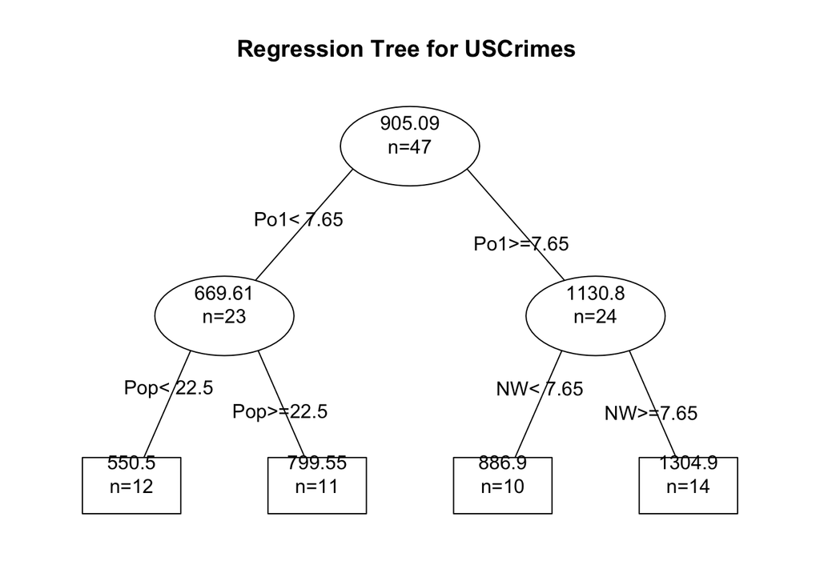

```r
post(m1, file = "",
   title = "Regression Tree for USCrimes ")
```

The regression tree using rpart splits the uscrimes data set into four sub sets using the factors P01, Pop and NW. The modeling is predicting the crimes to be 550.5 (far left) Po1 is less than 7.65 and Pop is less than 22.5. Similarly, it predict crime amount to be 799.55 when Pop is greater than 22.5.

From the plotted tree we can derive the rest of the model prediction for the different branches of conditions.

```r
library(randomForest)
fit <- randomForest(formula,data=dat)
print(fit) # view results
```

```
##
## Call:
##  randomForest(formula = formula, data = dat)
##                Type of random forest: regression
##                      Number of trees: 500
## No. of variables tried at each split: 5
##
##           Mean of squared residuals: 82993.23
##                     % Var explained: 43.31
```

```r
importance(fit) # importance of each predictor
```

```
##        IncNodePurity
## M          253025.41
## So          18530.98
## Ed         229923.11
## Po1       1255104.42
## Po2        997497.37
## LF         305475.85
## M.F        257304.53
## Pop        287129.63
## NW         509188.19
## U1         131709.56
## U2         172334.08
## Wealth     653051.11
## Ineq       224558.66
## Prob       800439.47
## Time       196743.24
```

When using a random forest model, random forest gives most importance to Po1.

Problem 10.2 Describe a situation or problem from your job, everyday life, current events, etc., for which a logistic regression model would be appropriate. List some (up to 5) predictors that you might use.

I think logistic regression can help with answering the question whether a new driver will have one or more car accidents within the first year of driving. Some of the predictors I’ll use are - Age of new driver - Driving Education - Hours of Driving practice - Family members with driving experience - Expected mileage of commuting for the year

Problem 10.3.1 Using the GermanCredit data set germancredit.txt from http://archive.ics.uci.edu/ml/machine-learning-databases/statlog/german / (description at http://archive.ics.uci.edu/ml/datasets/Statlog+%28German+Credit+Data%29 ), use logistic regression to find a good predictive model for whether credit applicants are good credit risks or not. Show your model (factors used and their coefficients), the software output, and the quality of fit. You can use the glm function in R. To get a logistic regression (logit) model on data where the response is either zero or one, use family=binomial(link=”logit”) in your glm function call.

```r
germanCredit <- read.table('germancredit.txt', stringsAsFactors=FALSE, header=FALSE)
head(germanCredit)
```

```
##    V1 V2  V3  V4   V5  V6  V7 V8  V9  V10 V11  V12 V13  V14  V15 V16  V17
## 1 A11  6 A34 A43 1169 A65 A75  4 A93 A101   4 A121  67 A143 A152   2 A173
## 2 A12 48 A32 A43 5951 A61 A73  2 A92 A101   2 A121  22 A143 A152   1 A173
## 3 A14 12 A34 A46 2096 A61 A74  2 A93 A101   3 A121  49 A143 A152   1 A172
## 4 A11 42 A32 A42 7882 A61 A74  2 A93 A103   4 A122  45 A143 A153   1 A173
## 5 A11 24 A33 A40 4870 A61 A73  3 A93 A101   4 A124  53 A143 A153   2 A173
## 6 A14 36 A32 A46 9055 A65 A73  2 A93 A101   4 A124  35 A143 A153   1 A172
##   V18  V19  V20 V21
## 1   1 A192 A201   1
## 2   1 A191 A201   2
## 3   2 A191 A201   1
## 4   2 A191 A201   1
## 5   2 A191 A201   2
## 6   2 A192 A201   1
```

```r
## Adding headers
colnames(germanCredit) <- c("CheckingAccountStatus","DurationMonths","CreditHistory",
                            "Purpose","CreditAmount","SavingAccountBonds","PresentEmploymentSince",
                            "InstallmentRatePercentageOfDisposableIncome","PersonalStatusAndSex",
                            "OtherDebtorsGurantors","PresentResidenceSince","Property",
                            "AgeInYears","InstallmentPlans","Housing","ExistingCreditsAtBank",
                            "Job","Dependents","Telephone","ForeignWorker","CreditClassification")

## Changing CreditClassification from 1-2 (Good-Bad) to 0-1(Good-Bad)
germanCredit$CreditClassification[germanCredit$CreditClassification == 1] <- 0
germanCredit$CreditClassification[germanCredit$CreditClassification == 2] <- 1
head(germanCredit)
```

```
##   CheckingAccountStatus DurationMonths CreditHistory Purpose CreditAmount
## 1                   A11              6           A34     A43         1169
## 2                   A12             48           A32     A43         5951
## 3                   A14             12           A34     A46         2096
## 4                   A11             42           A32     A42         7882
## 5                   A11             24           A33     A40         4870
## 6                   A14             36           A32     A46         9055
##   SavingAccountBonds PresentEmploymentSince
## 1                A65                    A75
## 2                A61                    A73
## 3                A61                    A74
## 4                A61                    A74
## 5                A61                    A73
## 6                A65                    A73
##   InstallmentRatePercentageOfDisposableIncome PersonalStatusAndSex
```

[output cut: 27 more lines]

```r
## splitting data
train <- germanCredit[1:500,]
test <- germanCredit[501:1000,]
formula2 <- CreditClassification ~ CheckingAccountStatus + DurationMonths + CreditHistory +Purpose + CreditAmount + SavingAccountBonds + PresentEmploymentSince + InstallmentRatePercentageOfDisposableIncome + PersonalStatusAndSex + OtherDebtorsGurantors + PresentResidenceSince + Property + AgeInYears + InstallmentPlans + Housing + ExistingCreditsAtBank + Job + Dependents + Telephone + ForeignWorker

logRegModel <- glm(formula=formula2, family=binomial(link="logit"), data=germanCredit)
summary(logRegModel)
```

```
##
## Call:
## glm(formula = formula2, family = binomial(link = "logit"), data = germanCredit)
##
## Deviance Residuals:
##     Min       1Q   Median       3Q      Max
## -2.3410  -0.6994  -0.3752   0.7095   2.6116
##
## Coefficients:
##                                               Estimate Std. Error z value
## (Intercept)                                  4.005e-01  1.084e+00   0.369
## CheckingAccountStatusA12                    -3.749e-01  2.179e-01  -1.720
## CheckingAccountStatusA13                    -9.657e-01  3.692e-01  -2.616
## CheckingAccountStatusA14                    -1.712e+00  2.322e-01  -7.373
## DurationMonths                               2.786e-02  9.296e-03   2.997
## CreditHistoryA31                             1.434e-01  5.489e-01   0.261
## CreditHistoryA32                            -5.861e-01  4.305e-01  -1.362
## CreditHistoryA33                            -8.532e-01  4.717e-01  -1.809
## CreditHistoryA34                            -1.436e+00  4.399e-01  -3.264
## PurposeA41                                  -1.666e+00  3.743e-01  -4.452
## PurposeA410                                 -1.489e+00  7.764e-01  -1.918
## PurposeA42                                  -7.916e-01  2.610e-01  -3.033
## PurposeA43                                  -8.916e-01  2.471e-01  -3.609
## PurposeA44                                  -5.228e-01  7.623e-01  -0.686
## PurposeA45                                  -2.164e-01  5.500e-01  -0.393
## PurposeA46                                   3.628e-02  3.965e-01   0.092
## PurposeA48                                  -2.059e+00  1.212e+00  -1.699
## PurposeA49                                  -7.401e-01  3.339e-01  -2.216
## CreditAmount                                 1.283e-04  4.444e-05   2.887
## SavingAccountBondsA62                       -3.577e-01  2.861e-01  -1.250
## SavingAccountBondsA63                       -3.761e-01  4.011e-01  -0.938
## SavingAccountBondsA64                       -1.339e+00  5.249e-01  -2.551
## SavingAccountBondsA65                       -9.467e-01  2.625e-01  -3.607
## PresentEmploymentSinceA72                   -6.691e-02  4.270e-01  -0.157
## PresentEmploymentSinceA73                   -1.828e-01  4.105e-01  -0.445
## PresentEmploymentSinceA74                   -8.310e-01  4.455e-01  -1.866
## PresentEmploymentSinceA75                   -2.766e-01  4.134e-01  -0.669
## InstallmentRatePercentageOfDisposableIncome  3.301e-01  8.828e-02   3.739
## PersonalStatusAndSexA92                     -2.755e-01  3.865e-01  -0.713
## PersonalStatusAndSexA93                     -8.161e-01  3.799e-01  -2.148
```

[output cut: 64 more lines]

```
## JobA173                                     0.397015
## JobA174                                     0.469086
## Dependents                                  0.288249
## TelephoneA192                               0.136060
## ForeignWorkerA202                           0.026095 *
## ---
## Signif. codes:  0 '***' 0.001 '**' 0.01 '*' 0.05 '.' 0.1 ' ' 1
##
## (Dispersion parameter for binomial family taken to be 1)
##
##     Null deviance: 1221.73  on 999  degrees of freedom
## Residual deviance:  895.82  on 951  degrees of freedom
## AIC: 993.82
##
## Number of Fisher Scoring iterations: 5
```

It appears that InstallmentRatePercentageOfDisposableIncome, SavingAccountBondsA65 (no saving account), PurposeA43 (radio/television), PurposeA41 (used car), CheckingAccountStatusA14 (No Checking account) are statistically significant with not having checking account having the lowest p-value suggesting an association of not having checking account to credit classification.

```r
anova(logRegModel, test="Chisq")
```

```
## Analysis of Deviance Table
##
## Model: binomial, link: logit
##
## Response: CreditClassification
##
## Terms added sequentially (first to last)
##
##
##                                             Df Deviance Resid. Df
## NULL                                                          999
## CheckingAccountStatus                        3  131.336       996
## DurationMonths                               1   38.497       995
## CreditHistory                                4   29.311       991
## Purpose                                      9   33.509       982
## CreditAmount                                 1    1.504       981
## SavingAccountBonds                           4   19.068       977
## PresentEmploymentSince                       4   12.496       973
## InstallmentRatePercentageOfDisposableIncome  1   11.907       972
## PersonalStatusAndSex                         3    9.459       969
## OtherDebtorsGurantors                        2    8.137       967
## PresentResidenceSince                        1    0.155       966
## Property                                     3    2.520       963
## AgeInYears                                   1    3.725       962
## InstallmentPlans                             2    8.357       960
## Housing                                      2    3.517       958
## ExistingCreditsAtBank                        1    2.328       957
## Job                                          3    1.110       954
## Dependents                                   1    1.049       953
## Telephone                                    1    1.863       952
## ForeignWorker                                1    6.063       951
##                                             Resid. Dev  Pr(>Chi)
## NULL                                           1221.73
## CheckingAccountStatus                          1090.39 < 2.2e-16 ***
## DurationMonths                                 1051.90 5.485e-10 ***
## CreditHistory                                  1022.58 6.759e-06 ***
## Purpose                                         989.08 0.0001089 ***
## CreditAmount                                    987.57 0.2200237
## SavingAccountBonds                              968.50 0.0007623 ***
## PresentEmploymentSince                          956.01 0.0140190 *
## InstallmentRatePercentageOfDisposableIncome     944.10 0.0005594 ***
## PersonalStatusAndSex                            934.64 0.0237759 *
## OtherDebtorsGurantors                           926.51 0.0171062 *
## PresentResidenceSince                           926.35 0.6934956
## Property                                        923.83 0.4717369
## AgeInYears                                      920.11 0.0536071 .
## InstallmentPlans                                911.75 0.0153184 *
## Housing                                         908.23 0.1723184
## ExistingCreditsAtBank                           905.90 0.1270420
## Job                                             904.79 0.7745757
## Dependents                                      903.74 0.3057414
## Telephone                                       901.88 0.1722319
## ForeignWorker                                   895.82 0.0138015 *
## ---
## Signif. codes:  0 '***' 0.001 '**' 0.01 '*' 0.05 '.' 0.1 ' ' 1
```

```r
library(pscl)
pR2(logRegModel)
```

```
##          llh      llhNull           G2     McFadden         r2ML
## -447.9088927 -610.8643021  325.9108186    0.2667620    0.2781304
##         r2CU
##    0.3943548
```

Problem 10.3.2 Because the model gives a result between 0 and 1, it requires setting a threshold probability to separate between “good” and “bad” answers. In this data set, they estimate that incorrectly identifying a bad customer as good, is 5 times worse than incorrectly classifying a good customer as bad. Determine a good threshold probability based on your model.

A good threshold would be 0.1. If .5 is both classification are evenly costly. Using that threshold, it appears the model will only be 0.564 accurate.

```r
fitted.results <- predict(logRegModel,newdata=subset(test,select=c(1,2,3,4,5,6,7,8,9,10,11,12,13,14,15,16,17,18,19,20)),type='response')
fitted.results <- ifelse(fitted.results > 0.1,1,0)
misClasificError <- mean(fitted.results != test$CreditClassification)
print(paste('Accuracy',1-misClasificError))
```

```
## [1] "Accuracy 0.564"
```

```r
library(ROCR)
```

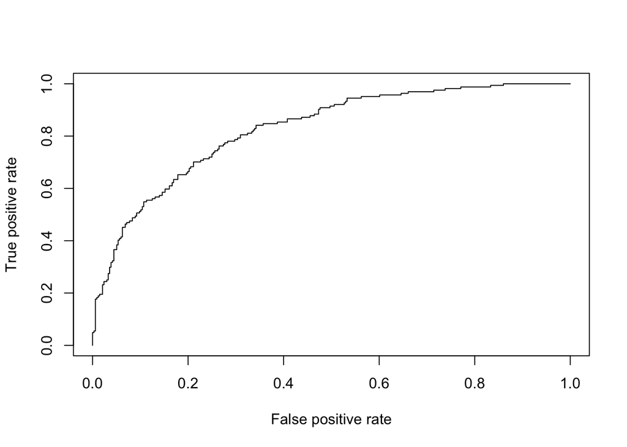

```r
p <- predict(logRegModel, newdata=subset(test,select=c(1,2,3,4,5,6,7,8,9,10,11,12,13,14,15,16,17,18,19,20)), type="response")
pr <- prediction(p, test$CreditClassification)
prf <- performance(pr, measure = "tpr", x.measure = "fpr")
plot(prf)
```

```r
auc <- performance(pr, measure = "auc")
auc <- auc@y.values[[1]]
auc
```

```
## [1] 0.8260017
```

Code Inspiration Source - https://datascienceplus.com/perform-logistic-regression-in-r/